# Coding fundamentals for humanists

A course overview

[figure not shown]

[figure not shown]

# The course

## Goal

Demystify coding

Give you confidence

Explain foundational concepts

Give you tools for your research

## Who should attend?

Anyone without any coding experience who would like to use coding for their research or who is interested in understanding what coding is and how it works

This course is particularly useful as a prerequisite to other DHSI courses using Python

## Overview

Core concepts of programming languages

Introduction to JupyterLab

Basics of Python

Using LLMs to write code

API querying in Python

Web scraping with Python

Your turn: get data from a website

Presentations: share what you learnt

# In practice

## Website

Each year we build a website

Easier for attendees to follow along, copy code snippets, etc.

The sites never get taken down so attendees can rely on them to find information later on

[interactive chart not shown]

## Presentation

We start the course with a presentation explaining the concepts

[interactive chart not shown]

## Hands-on

Then move to hands-on

[interactive chart not shown]

## JupyterLab

We use the free and open-source [JupyterLab](https://jupyter.org/) as an interface to Python to make it easier to play with code

[interactive chart not shown]

## We write the Jupyter notebooks in advance

### Example of notebook you will download:

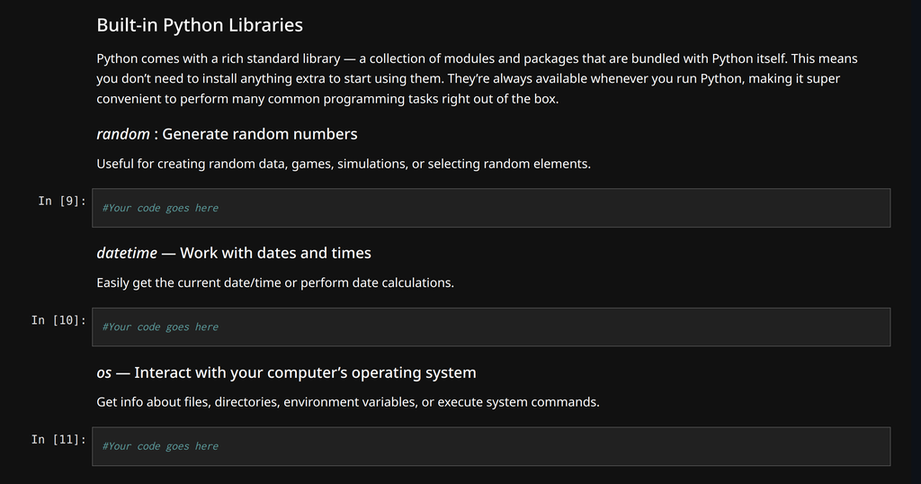

## And we let you fill in the code

### Example of completed notebook:

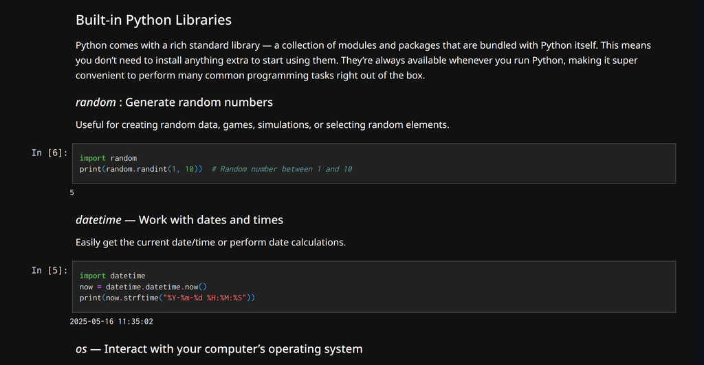

## Guidance on using LLMs

When used well, large language models can allow students:

- To be much more independent
- Not to get frustrated over small road-blocks
- To go much further faster
- To keep learning on their own
- To be able to apply Python to their research

We will show you what works and what doesn’t when using LLMs to write code

# What you will be able to do

## End of course projects

At the end of the course, attendees work in pairs on a project of their choice (which can be their own research) with our help

Following are samples of data our past students successfully scraped from various websites

## Guardian archives

[figure not shown]

## Spotify playlist

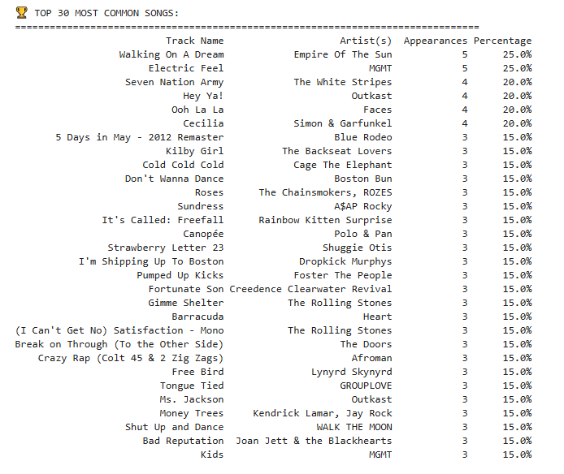

## Numbers of published books

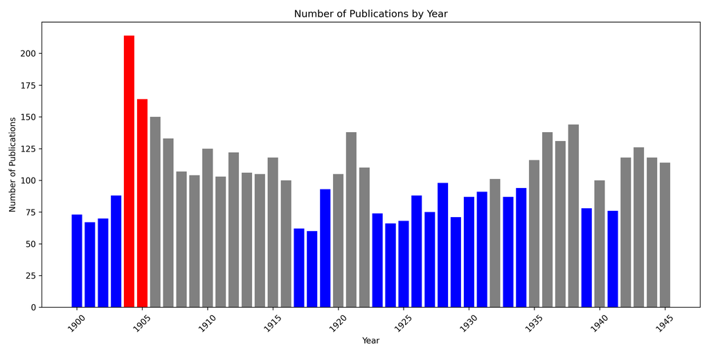

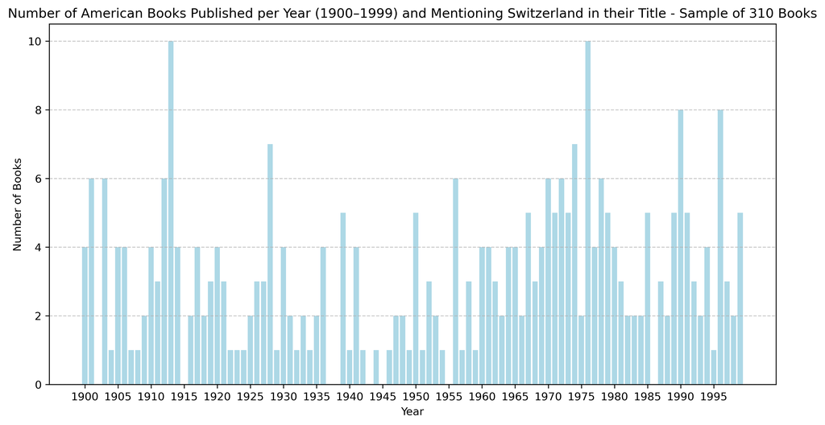

## Reddit data

### Exported as a Python list:

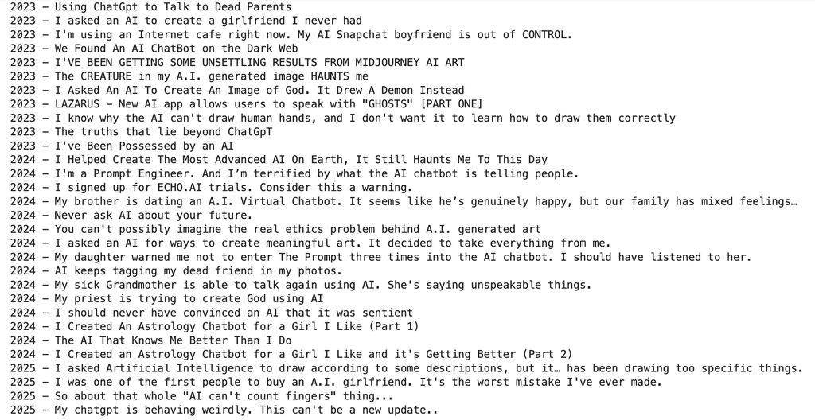

### Exported as a Python [polars](https://pola.rs/) data frame:

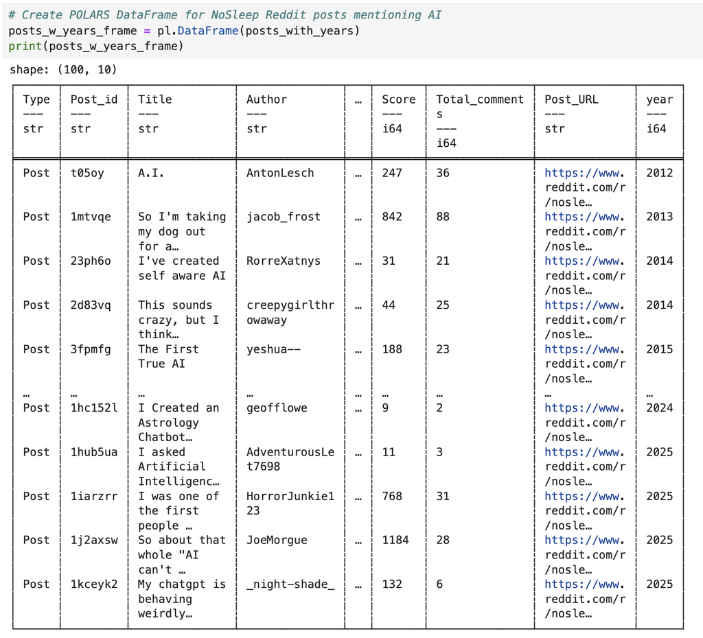